# Inferência musical - LastFM

Helder Machado de Lima

## Proporção de artistas novos e popularidade

Utilizaremos ICs para estimar duas métricas sobre os usuários do LastFM em geral durante um período de 6 meses. Em ambos os casos faremos isso a partir de uma amostra de 300 usuários. As duas métricas são:

### 1. Qual a proporção de novos artistas em geral escutada por usuários?

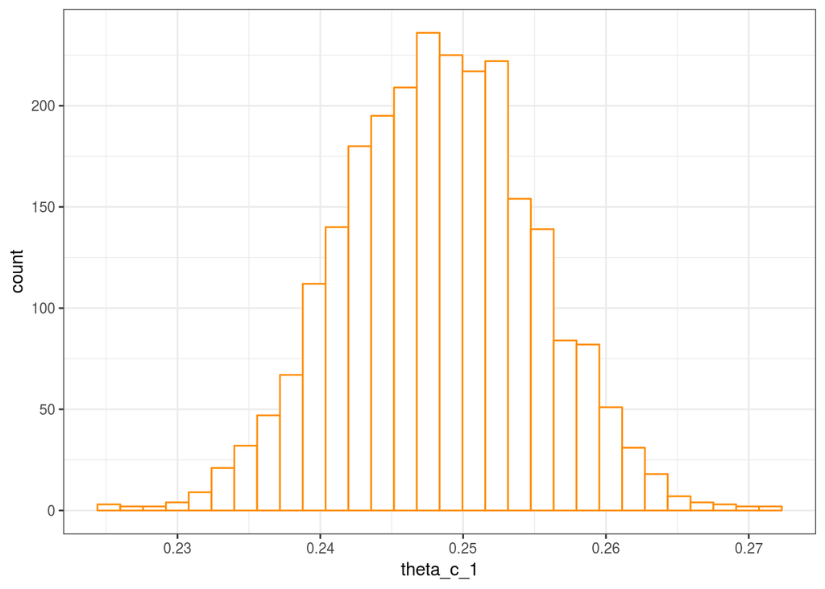

```r
set.seed(12345)
#https://github.com/cienciadedados-ufcg/inferencia-lastfm

last_fm = read_csv(here::here("data/experimento-lastfm.csv"),
                  col_types = cols(.default = col_double(),
                                   user = col_character()))

lastfm = last_fm %>% sample_n(300) %>% select(news, old, mediana_pop)

comp_theta = function(df) { df %>% pull(news_prop) %>% mean() }

lastfm <- lastfm  %>% mutate(news_prop = (news / (news + old)))

theta_new = comp_theta(lastfm)
lastfm <- lastfm %>% sample_n(300) %>% select(news, old, mediana_pop, news_prop)

# glimpse(lastfm)

um_bootstrap <- function(x){
    reamostra = x %>% sample_n(size = NROW(x), replace = TRUE)
    new_props = reamostra %>% mutate(news_prop = (news / (news + old))) %>% pull(news_prop)
    return(mean(new_props))
}

# um_bootstrap(lastfm)


um_bootstrap <- function(x){
  boot_1 <- sample_n(x, size = NROW(x), replace = TRUE)
  theta_c_1 = comp_theta(boot_1)

  return(theta_c_1)
}
reamostragens = tibble(i = 1:2500) %>%
  mutate(theta_c_1 = map_dbl(i, ~ um_bootstrap(lastfm)))

# reamostragens

reamostragens %>%
  ggplot(aes(x = theta_c_1)) +
  geom_histogram(colour = "darkorange", fill = "white")
```

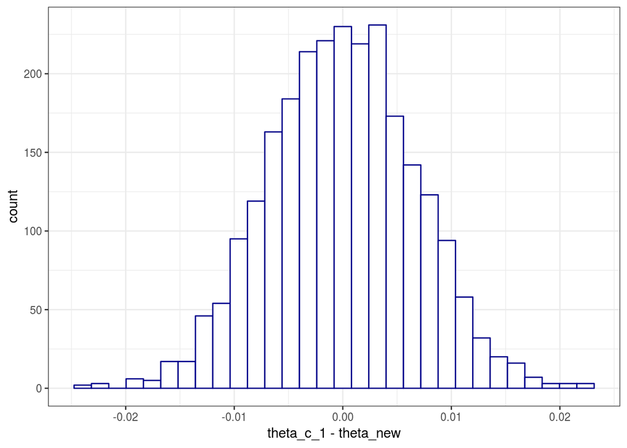

```r
reamostragens %>%
  ggplot(aes(x = theta_c_1 - theta_new)) +
  geom_histogram(colour = "darkblue", fill = "white")
```

### Calculando os IC

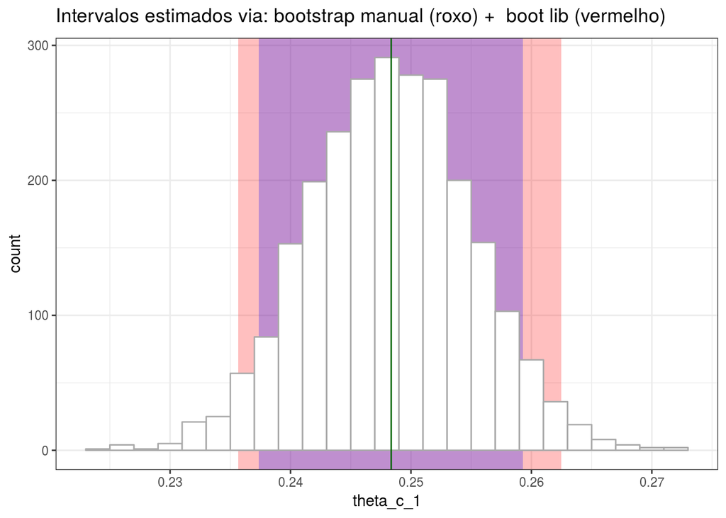

```r
intervalo = reamostragens %>%
  mutate(erro = theta_c_1 - theta_new) %>%
  summarise(erro_i = quantile(erro, .05), valor_i = theta_new + erro_i,
            erro_s = quantile(erro, .95), valor_s = theta_new + erro_s)
# intervalo

theta_interval = function(df, i) { df %>% slice(i) %>% pull(news_prop) %>% mean() }

booted <- boot(data = lastfm, statistic = theta_interval, R = 2500)
interval_boot <- boot.ci(booted, conf=.95, type="bca")
# interval_boot$t0
# interval_boot$bca[4]
# interval_boot$bca[5]

ggplot() +
  geom_rect(data = intervalo, aes(xmin = interval_boot$bca[4], xmax = interval_boot$bca[5]), ymin = -Inf, ymax = Inf, fill = "red", alpha = .25) +
  geom_rect(data = intervalo, aes(xmin = valor_i, xmax = valor_s), ymin = -Inf, ymax = Inf, fill = "blue", alpha = .25) +
  geom_histogram(data = reamostragens, aes(theta_c_1), binwidth = .002, fill = "white", colour = "darkgrey") +
    geom_vline(xintercept = theta_new, color = "darkgreen", size = .5) +
  labs(title = expression("Intervalos estimados via: bootstrap manual (roxo) +  boot lib (vermelho)"))
```

### Avaliação dos resultados:

Para a primeira pergunta, conseguimos verificar que o intervalo de confiança calculado manualmente **[0.237;0.259]**(roxo) é bem próximo do calculado usando a biblioteca boot **[0.235;0.262]**(vermelho). Também podemos perceber que algo próximo a 25% escutam novos artitas, que está dentro dos intervalos que nós encontramos. A linha verde mostra o valor da média encontrada **0.248**.

### 2. Para os usuários que gostam de música muito pop (mediana_pop > 5), qual a correlação entre a popularidade mediana dos artistas escutado e a proporção dos artistas escutados que eram novos.

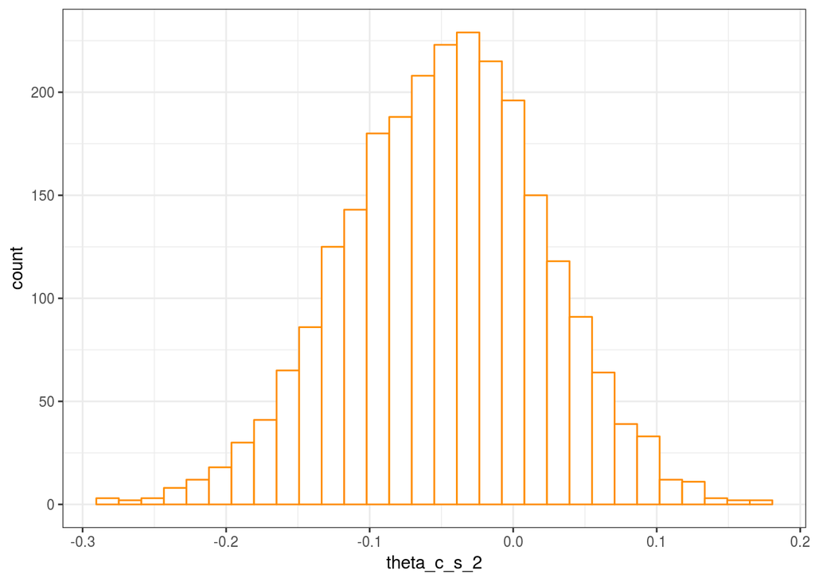

```r
set.seed(1245)
comp_theta_cor = function(df) { df %>% filter(mediana_pop > 5) %>% summarise(corr_news_med = cor(news_prop, mediana_pop)) %>% pull(corr_news_med) }


theta_new_corr = comp_theta_cor(lastfm)

um_bootstrap <- function(x){
    reamostra = x %>% sample_n(size = NROW(x), replace = TRUE)
    corr_news_med = reamostra %>% mutate(corr_news_med = cor(news_prop, mediana_pop)) %>% pull(corr_news_med)
    return(mean(corr_news_med))
}

# um_bootstrap(lastfm)

set.seed(1245)

reamostragens_2 = tibble(i = 1:2500) %>%
  mutate(theta_c_s_2 = map_dbl(i, ~ um_bootstrap(lastfm)))

# reamostragens

reamostragens_2 %>%
  ggplot(aes(x = theta_c_s_2)) +
  geom_histogram(colour = "darkorange", fill = "white")
```

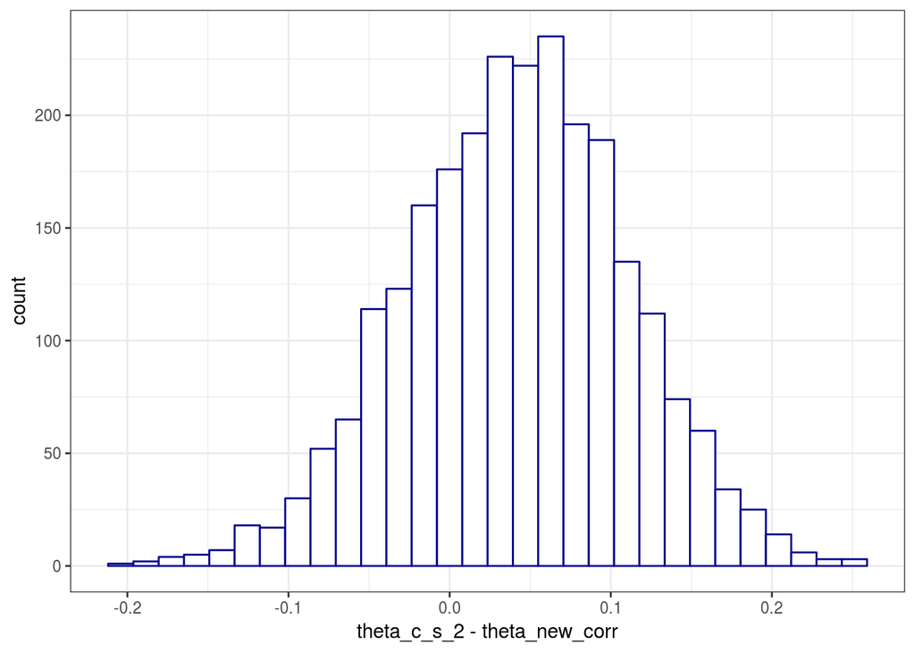

```r
reamostragens_2 %>%
  ggplot(aes(x = theta_c_s_2 - theta_new_corr)) +
  geom_histogram(colour = "darkblue", fill = "white")
```

### Calculando os IC

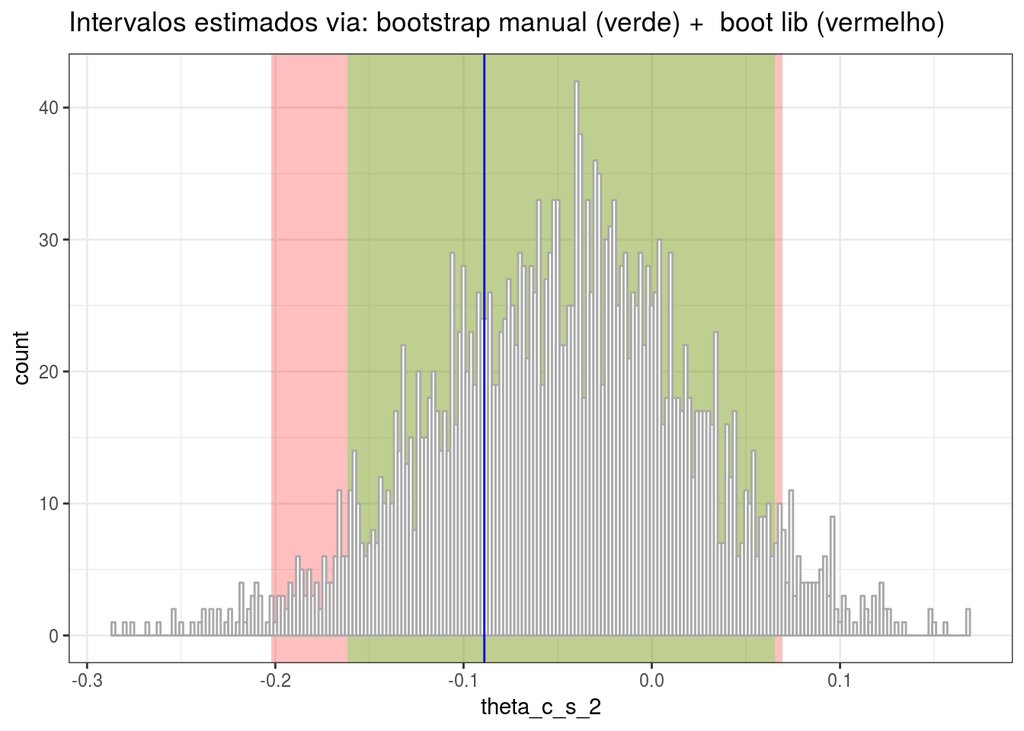

```r
set.seed(1245)
intervalo_2 = reamostragens_2 %>%
  mutate(erro = theta_c_s_2 - theta_new_corr) %>%
  summarise(erro_i = quantile(erro, .05), valor_i_2 = theta_new_corr + erro_i,
            erro_s = quantile(erro, .95), valor_s_2 = theta_new_corr + erro_s)
# intervalo

theta_interval = function(df, i) { df %>% slice(i) %>% summarise(corr_news_med = cor(news_prop, mediana_pop)) %>% pull(corr_news_med) }

booted2 <- boot(data = lastfm, statistic = theta_interval, R = 2500)
interval_boot_2 <- boot.ci(booted2, conf=.95, type="bca")
# interval_boot_2$bca[4]
# interval_boot_2$bca[5]

ggplot() +
  geom_rect(data = intervalo_2, aes(xmin = interval_boot_2$bca[4], xmax = interval_boot_2$bca[5]), ymin = -Inf, ymax = Inf, fill = "red", alpha = .25) +
  geom_rect(data = intervalo_2, aes(xmin = valor_i_2, xmax = valor_s_2), ymin = -Inf, ymax = Inf, fill = "green", alpha = .25) +
  geom_histogram(data = reamostragens_2, aes(theta_c_s_2), binwidth = .002, fill = "white", colour = "darkgrey") +
  geom_vline(xintercept = theta_new_corr, color = "blue", size = .5) +
  labs(title = expression("Intervalos estimados via: bootstrap manual (verde) +  boot lib (vermelho)"))
```